# R Tutorial, BEE 2026

Journey Keen & Richard J. Liu

2026-05-15

## Part 1: Introduction

This was made so that students in the Minneapolis Fed’s BEE Program have an introduction and some reference to data analysis with R, especially with graphing.

You, the student, should follow along. I will be placing the exact code and output for these notes in this document, but you should produce the code yourself to verify that you get the same output. Along with this pdf document, you should also download the files “example_file.csv” and “percentiles_combined.csv” for your scripts to work. You will also need the directory you put them in (which, for now, should be in the same folder as this pdf you downloaded and are reading, as well as your R script you will start to follow-along). The “directory” is just the entire path
$$C:/Users/person/Desktop/folder\_1/folder\_2/data\_folder/$$
but we might refer to the last folder in it, $/data\_folder/$, as the folder.

Excel is nice because you can see the underlying data right in front of you when you perform any analysis with the data. This is in contrast to a lot of computer programs where the data needs to be “printed” out to see anything. R allows a little bit of both, where your programming that reads like a left-indented text with a lot of newline characters and data are like tabs in an internet browser. You can switch between them pretty easily. What makes R (and other statistical programming languages) better is that you can do a lot more with them and the analysis is more ``systematic.’’

What this means is that R is a programming language (kind of). You can create variables and data, and you interact with them via text like this (do *not* run this code; it is for reference):

```r
#### Do NOT type this -- Example only ####
example_data = data.table(year=2005:2007, value = 1:3)

x = 7
y = 4
z = x + y
```

Here the data “table” (which can be thought of as a dataset in excel, with rows and columns) and the variables `x`, `y`, and `z` are created. `z` is created from other variables. This is part of a “script,” which you save and can run later to produce exactly the same data and, later, output.

You will work in Rstudio, which is just a nice interface for using R. I attached a screenshot of what it looks like with my annotations for the four main sections in Rstudio.

[figure not shown]

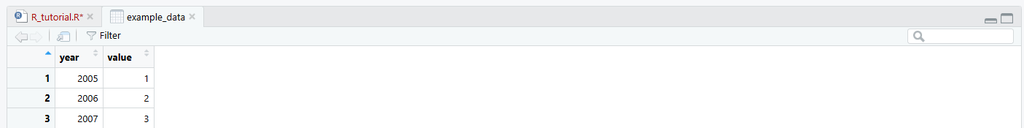

# Programs

The “programs” section of Rstudio is where the programs can be viewed and edited and where data can be viewed. It is where you “code”. Unlike in Excel, data cannot be changed by clicking on the data and typing anything: It must be changed by an actual program (or in the “console” section, but ignore that for now). The R text earlier was a quick example. After editing, you save programs in this section (or “scripts”) to your computer to save your work. It is like writing down your solutions to a homework problem so that you or someone else have the “code” to produce what you were working on earlier.

# Environment

The “environment” section shows which variables and tables you have created (and so are “in memory”). You can think of it as R keeping a log of the work you have done so you know what is loaded. In the annotated example it is empty. To view a data table you can just click on it and Rstudio will put it in as a tab in the programs section. You can also view data in the environment via the “console” section.

# Console

The “console” section is how you run code one line at a time, rather than part of a programming script in the programs section. This is useful when you might want intermediate code that is not to be saved to a program/script. For example, you might not want to save `x*y` to the environment or your larger project, but while coding you want to see what it looks like real quick. It is also where a lot of output goes, at least for our purposes here. In the earlier program we saved the variable `z=x+y` to our environment, but if we just wrote `x+y`, which does not save the value of x plus y to a variable but just computes it, then the output will be printed to the console rather than being saved to the environment as a variable, `z`. Here is what the console looks like if we created `x` and `y` in the console and then just wanted to quickly look at the value of `x+y`:

```
## [1] 11
```

You can do the same by typing in each “line” (which are marked by the `>`) and pressing enter. Note that output has the `[1]` in front. Now, this is a silly example. We can do $7+4$ in our head pretty easily. This is just to demonstrate how it works. We can just as well put much more complicated things in the console that are intermediate checks for something that we do not want in our actual script.

The last section is what I called “Plots and Help.” The console is where data output goes, and this is where plotting and graphical output goes. If you know a command but want the specifics of it, you can also type `?command` to get a file that explains the command. If you want to be more vague (e.g. if you forgot the actual name of the command you want to use) then you can use two question marks: `??command_guess`. Yes, these helper things have mostly been replaced by AI. Sometimes they are quicker, though. You will rarely use the other tabs in this section and probably not at all in these two weeks.

# R Basics

Here I will introduce how to actually program in R. You got a very small taste of it in the last section.

The first thing to do is to load-in common “packages.” A package is just more of R you can use. Packages like downloading the Uber app on your phone, whereas base R has just the pre-installed apps, like messages or calls. You download apps and packages so your phone and R can do more. Today we will only use one package, `data.table`. This gives us access to Excel-like tools. To install it, we use `install.packages()`, and then put the name of the package inside the parenthesis in quotes. This is like an app store: You only need to install them once. Do this:

```r
install.packages("data.table")

library(data.table)
```

Depending upon which files you have downloaded, this will put some text in your console. That is fine, unless it is an error. You should be able to igore this.

The part `library()` is to actually load the package into your current R environment. Although you only need to install them once, you will need to put this at the top of every R script you have.

## Variable Creation

To create a variable you have a name for it and information to attach to it. I use “information” very loosely here; it can mean a real number, a vector, a matrix, or a table (variables and rows as in excel). When creating, you go by the format
$$`name =
information`$$
You can use the characters `<-` instead of the equals sign, `=`. They mean the same thing: Assign the information on the right to the name on the left. For example, earlier `variable_name` was “x” and `information` was “7.”

## Logical Operators

Next are logical operators. They check if something is true or false, which in R are the logical values `TRUE` (or just `T`) and `FALSE` (or just `F`). When working with data we frequently want to subset the data to something, where we only care about what we want to subset to. For instance, if you have data from $1990$ to $2025$ but only want to look at data in-and-around the pandemic, then you might to subset your data to years $2018$ to $2023$. If our data table has a variable `year`, then we need to get the rows where this variable is in this interval of years. That is a true or false condition.

The common ones are

| Operator | `&` | `\|` | `==` | `!=` | `<`, `>` | `<=`, `>=` |
| --- | --- | --- | --- | --- | --- | --- |
| English Name | And | Or | Equals | Not Equals | Less than, Greater than | Less than or equals… |

For instance, `7==5` returns FALSE. `7==7` returns TRUE. We use the “and” and “or” operators to chain multiple expressions together, for example to check a condition for one variable and/or another condition for another variable. `TRUE == (TRUE | FALSE)` returns `TRUE`, since the right-hand-side evaluates to true as an “or” condition. But, `TRUE == (TRUE & FALSE)` returns `FALSE`, since the right-hand-side then is false. An example with variables in a data table is `year <= 2017 & color=="Blue"` which returns rows where the year variable is less than or equal to $2017$ *and* the color variable is exclusively the text “Blue”. If we instead had `year <= 2017 | color=="Blue"`, then we will get rows where the year variable is less than or equal to $2017$ *or* where the color variable is the text “Blue”. Rows then only need one of, or both, of these conditions.

## Vectors

Data science is just dealing with vectors and matrices. For our purposes a vector is just a “list” of another object, like real numbers, integers, characters, or even other vectors. In R we create vectors with `c()` like this:

```r
vec_numbers = c(1,2,3,4)

vec_characters <- c("A", "B", "word")

vec_numbers_alt = c(5,6,9,10)

length(vec_numbers)
```

```
## [1] 4
```

I also made an example of using `=` and `<-` for assignment. Again, they do the same thing. I returned the length of `vec_numbers` to demonstrate that we control the length of a vector when we create it. Here is the same but for `vec_characters`.

```r
length(vec_characters)
```

```
## [1] 3
```

You can access a specific value in a vector by giving R its position, called an **index**. For example, in `c("A", "B", "word")`, the first value is `"A"`, the second value is `"B"`, and the third value is `"word"`.

```r
vec_characters[3]
```

```
## [1] "word"
```

This returns “word”, since that is at the third index.

We can access the information in a vector in different ways than just using the position of each value. In fact, using the exact position is rare. We usually want to get values from a vector only when some condition is true. To do this, we can give R a logical vector, which is a vector filled with `TRUE`s and `FALSE`s. R then returns the values where the logical vector is `TRUE`.

```r
vec_characters[c(TRUE, FALSE, TRUE)]
```

```
## [1] "A"    "word"
```

returns a smaller vector, of length two, with the information of the character vector’s first and third indices, since that is where the logical vector passed is true. Hence, you can see output is `c("A", "word")`. Try putting your own logical conditions in your own vectors.

If you want a shortcut to create “sequential” vectors of the form $(n, n+1, \dots, n+j)$, then you can use `n:(n+j)`. This is the same as manually typing `c(n, n+1,` and then all the way to `, n+j-1, n+j)` for numbers $n$ and $j$.

Vectors are important to be comfortable with because each column in a data table, our variables, are vectors. In fact, if you manually create a table (rather than loading-in an excel file or something), you are just telling R that a vector has a name, and then this named vector becomes a variable in the table. In our first example of R text

```r
example_data = data.table(year=2005:2007, value=1:3)
```

we told R the variable `year` is the vector `2005:2007` and the variable `value` is the vector `1:3`. (Recall that these are just `c(2005,2006,2007)` and `c(1,2,3)`, respectively.)

To give an example of where we would want logical conditions, create this in R:

```r
table = data.table(
  gender=c("Male", "Female"),
  value =c(10, 13)
)
```

We might want to create a row from these two rows where our new row is a ratio of Female to Male values. For example, this data could be average earnings. The code to do this is below. Focus only on the `ratio =` part. The rest I will cover later.

```r
table[, .(
  ratio = value[gender=="Female"]/value[gender=="Male"]
)]
```

```
##    ratio
##    <num>
## 1:   1.3
```

We access the row where gender is “Female” in the vector `value` and divide it by where this vector is “Male”. Yes, you can just look at it and give the answer easily here. If you wanted to do this directly with vectors instead of the table format you could have

```r
gender = c("Male", "Female")
value = c(10, 13)
value[gender=="Female"]/value[gender=="Male"]
```

```
## [1] 1.3
```

which returns $1.3=13/10$.

In a more realistic but more detailed version this data would exist over many years and there could potentially be information not related to gender in the table. You would not want to scroll over it every year to get the two values you want and then divide them all, manually. This is why we use R.

## Organization

One of the benefits to using statistical software like R is all of these saved scripts that are the blueprints of how to take some data and create other data, be it a regression/model summary, plots, or manipulated data to be used by another file. You will end-up creating a lot of files. You need to be organized in each file, across the files in a project you are working on, and across the projects you may or may not be working on.

There is a lot of literature on how to stay organized here. It is extremely important, and in more recent years economists with computer science backgrounds (software engineers deal with programs with several thousand times the complexity in terms of how messy their files can potentially be compared to economists, and so they typically are quite good at this) have pushed for doing this better.

At some point you will have to do this. I do not think you should worry about it now, if this is your first time using programming or statistical software. The best way to learn this is probably the hard way: Burn your finger, say mean things, and figure out fire is hot. Poorly label a bunch of files, put dates onto files, do not comment on what your code is doing. Erase your work from your mind, come back a week later, and pick-up where you left off. Your finger is now burnt. So, waste an hour (with mean words) trying to find where and what you were working on. You will re-organize a bunch of code in the process of doing this. You will then break the code because you forgot what was supposed to be ran first and other things that part of the code requires to run. And then you will learn fire is hot and how to use a rag when grabbing a hot pan: You will learn how to organize code, your projects, and how to record your work and edits thereof. But not now. For now just focus on writing those first few basic scripts.

# Part 2: Data visualization

### *BEE instructions*

*The following chapter will walk you through using **ggplot2**, an R package that allows you to make graphs in R. If you are already familiar with R/ggplot2 and want to skip ahead, go straight to the exercises - labeled ‘Data Visualization: Exercises 1/2/3/4’.*

*The following text is all excerpted from the free online textbook,* **R for Data Science (2e)**, *chapter 1, ‘Data visualization’ and chapter 6, ‘Workflow: scripts and projects’. Exercises and some text have been adjusted for brevity.*

## Introduction

> “The simple graph has brought more information to the data analyst’s mind than any other device.” — John Tukey

R has several systems for making graphs, but ggplot2 is one of the most elegant and most versatile. ggplot2 implements the **grammar of graphics**, a coherent system for describing and building graphs. With ggplot2, you can do more and faster by learning one system and applying it in many places.

This chapter will teach you how to visualize your data using **ggplot2**. We will start by creating a simple scatterplot and use that to introduce aesthetic mappings and geometric objects – the fundamental building blocks of ggplot2. We will then walk you through visualizing distributions of single variables as well as visualizing relationships between two or more variables. We’ll finish off with saving your plots and troubleshooting tips.

### Prerequisites

This chapter focuses on ggplot2, one of the core packages in the tidyverse. You’ll first need to install the tidyverse.

```r
install.packages("tidyverse")
```

To access the datasets, help pages, and functions used in this chapter, load the tidyverse by running:

```r
library(tidyverse)
```

That one line of code loads the core tidyverse; the packages that you will use in almost every data analysis. It also tells you which functions from the tidyverse conflict with functions in base R (or from other packages you might have loaded)[^1].

You only need to install a package once, but you need to load it by running `library(package_name_here)` every time you start a new session.

In addition to tidyverse, we will also use the **palmerpenguins** package, which includes the `penguins` dataset containing body measurements for penguins on three islands in the Palmer Archipelago, and the ggthemes package, which offers a colorblind safe color palette. Similar to the tidyverse package, if you have never installed these packages before, you’ll first have to install them:

```r
install.packages("palmerpenguins")
install.packages("ggthemes")
```

Before loading them:

```r
library(palmerpenguins)
library(ggthemes)
```

## First steps

Do penguins with longer flippers weigh more or less than penguins with shorter flippers? You probably already have an answer, but try to make your answer precise. What does the relationship between flipper length and body mass look like? Is it positive? Negative? Linear? Nonlinear? Does the relationship vary by the species of the penguin? How about by the island where the penguin lives? Let’s create visualizations that we can use to answer these questions.

### The `penguins` data frame

You can test your answers to those questions with the `penguins` **data frame** found in palmerpenguins (a.k.a. `palmerpenguins::penguins`). A data frame is a rectangular collection of variables (in the columns) and observations (in the rows). `penguins` contains 344 observations collected and made available by Dr. Kristen Gorman and the Palmer Station, Antarctica LTER[^2].

To make the discussion easier, let’s define some terms:

- A **variable** is a quantity, quality, or property that you can measure.
- A **value** is the state of a variable when you measure it. The value of a variable may change from measurement to measurement.
- An **observation** is a set of measurements made under similar conditions (you usually make all of the measurements in an observation at the same time and on the same object). An observation will contain several values, each associated with a different variable. We’ll sometimes refer to an observation as a data point.
- **Tabular data** is a set of values, each associated with a variable and an observation. Tabular data is *tidy* if each value is placed in its own “cell”, each variable in its own column, and each observation in its own row.

In this context, a variable refers to an attribute of all the penguins, and an observation refers to all the attributes of a single penguin.

Type the name of the data frame in the console and R will print a preview of its contents. Note that it says `tibble` on top of this preview. In the tidyverse, we use special data frames called **tibbles** that you will learn more about soon.

```r
penguins
```

```
## # A tibble: 344 × 8
##    species island    bill_length_mm bill_depth_mm flipper_length_mm body_mass_g sex     year
##    <fct>   <fct>              <dbl>         <dbl>             <int>       <int> <fct>  <int>
##  1 Adelie  Torgersen           39.1          18.7               181        3750 male    2007
##  2 Adelie  Torgersen           39.5          17.4               186        3800 female  2007
##  3 Adelie  Torgersen           40.3          18                 195        3250 female  2007
##  4 Adelie  Torgersen           NA            NA                  NA          NA <NA>    2007
##  5 Adelie  Torgersen           36.7          19.3               193        3450 female  2007
##  6 Adelie  Torgersen           39.3          20.6               190        3650 male    2007
##  7 Adelie  Torgersen           38.9          17.8               181        3625 female  2007
##  8 Adelie  Torgersen           39.2          19.6               195        4675 male    2007
##  9 Adelie  Torgersen           34.1          18.1               193        3475 <NA>    2007
## 10 Adelie  Torgersen           42            20.2               190        4250 <NA>    2007
## # ℹ 334 more rows
```

This data frame contains 8 columns. For an alternative view, where you can see all variables and the first few observations of each variable, use `glimpse()`. Or, if you’re in RStudio, run `View(penguins)` to open an interactive data viewer.

```r
glimpse(penguins)
```

```
## Rows: 344
## Columns: 8
## $ species           <fct> Adelie, Adelie, Adelie, Adelie, Adelie, Adelie, Adelie, Adelie, Adelie, …
## $ island            <fct> Torgersen, Torgersen, Torgersen, Torgersen, Torgersen, Torgersen, Torger…
## $ bill_length_mm    <dbl> 39.1, 39.5, 40.3, NA, 36.7, 39.3, 38.9, 39.2, 34.1, 42.0, 37.8, 37.8, 41…
## $ bill_depth_mm     <dbl> 18.7, 17.4, 18.0, NA, 19.3, 20.6, 17.8, 19.6, 18.1, 20.2, 17.1, 17.3, 17…
## $ flipper_length_mm <int> 181, 186, 195, NA, 193, 190, 181, 195, 193, 190, 186, 180, 182, 191, 198…
## $ body_mass_g       <int> 3750, 3800, 3250, NA, 3450, 3650, 3625, 4675, 3475, 4250, 3300, 3700, 32…
## $ sex               <fct> male, female, female, NA, female, male, female, male, NA, NA, NA, NA, fe…
## $ year              <int> 2007, 2007, 2007, 2007, 2007, 2007, 2007, 2007, 2007, 2007, 2007, 2007, …
```

Among the variables in `penguins` are:

1. `species`: a penguin’s species (Adelie, Chinstrap, or Gentoo).
2. `flipper_length_mm`: length of a penguin’s flipper, in millimeters.
3. `body_mass_g`: body mass of a penguin, in grams.

To learn more about `penguins`, open its help page by running `?penguins`.

### Ultimate goal

Our ultimate goal in this chapter is to recreate the following visualization displaying the relationship between flipper lengths and body masses of these penguins, taking into consideration the species of the penguin.

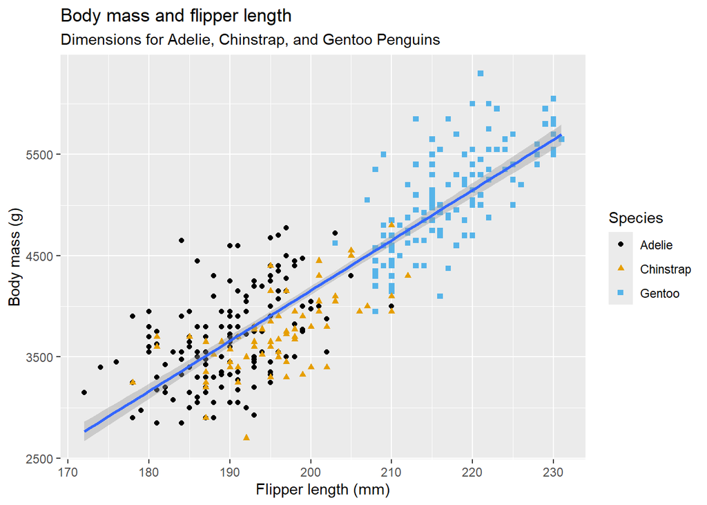